# 2018_midterm_Stroud

Hannah Stroud

October 26, 2018

## 1. Sampling your system (10 points)

#### Each of you has a study system your work in and a question of interest. Give an example of one variable that you would sample in order to get a sense of its variation in nature. Describe, in detail, how you would sample for the population of that variable in order to understand its distribution. Questions to consider include, but are not limited to: Just what is your sample versus your population? What would your sampling design be? Why would you design it that particular way? What are potential confounding influences of both sampling technique and sample design that you need to be careful to avoid? What statistical distribution might the variable take, and why?

I don’t deal with natural system and I’m not sure how to apply this question to what I study. See extra credit in attempt to make up missed points.

## 2. Let’s get philosophical. (10 points)

#### Are you a frequentist, likelihoodist, or Bayesian? Why? Include in your answer why you prefer the inferential tools (e.g. confidence intervals, test statistics, posterior probabilities, etc.) of your chosen worldview and why you do not like the ones of the other one. This includes defining just what those different tools mean! extra credit for citing and discussing outside sources - one point per source/point

I am a Bayesian. I think there is a communication issue with frequentist statistics to those who don’t deal with them and I feel like while they can be used for good, the p-value has been used without much thought at times, only relying on the 0.05 rule. I have found the idea “We teach it because it’s what we do; we do it because it’s what we teach” to be too often true(Cobb qtd. in Wasserstein & Lazar 2016). I like that Bayesian inference “provides an explicit expression of the amount of uncertainty” in estimates, which is a lot more useful than saying you rejected the null or not (Ellison 1996). It’s also As Ellison also points out, frequentist assumptions rely on true random sampling and a true fixed value for each parameter of interest- and neither of those seem to fit well for me (1996). Another big statistics and science communication element with Frequentist statistics relates to confidence intervals. Confidence intervals in frequentists statistics are frequently misinterpreted, because people read them as 95% confident that the true mean lies within the interval but really they mean “Under repeated sampling, the true mean will be inside the confidence interval 95% of the time” (“Abraham Lincoln and confidence intervals” https://andrewgelman.com/2016/11/23/abraham-lincoln-confidence-intervals/). I do find times where p-values, t-tests and other frequentist statistics are useful, but I feel like overall they aren’t used in the most useful way as the ASA guidelines from 2016 recommend.

Likelihood is more intuitive to mean than using t tests and p-values, but is still grounded in frequentist thought. Likelihood value only “gains meaning when compared the likelihoods of other possible values” (Whitlock & Schluter , p. 656). It samples all possible parameters within a range to find the one most likely to give the data you found. It is more versatile than least squares but falls short with complicated models.

Intuitively, the concept behind Bayesian statistics just fits better with how I view the world because it presents the confidence in a hypothesis given the data when frequentist and likelihood give the probability of the data given a hypothesis. I really like the idea and simplicity of priors and posteriors. Bayesian is a beautiful statistical circle of life: “we acquire data..update the posterior distribution…This updated distribution then serves as the prior” for future models. (Seeing Theory: https://seeing-theory.brown.edu/bayesian-inference/index.html#section1). Priors are really useful to me- they allow us to utilize the knowledge we already have about what we are studying and improve upon it, and incorporating priors just seems like a better idea than relying on random sampling that is never truly perfectly random or normally distributed. Bayesian modeling is also more versatile. We can model using Markov Chain Monte Carlo analysis, which allows us to model non-gaussian distributions and hierarchal relationships. Overall, while the code is longer, the Bayesian tools seem better applied to wide range of models and easier to communicate results.  
## 3. Power (20 points) #### We have a lot of aspects of the sample of data that we collect which can alter the power of our linear regressions.

#### Slope

#### Intercept

#### Residual variance

#### Sample Size

#### Range of X values

#### Choose three of the above properties and demonstrate how they alter power of an F-test from a linear regression using at least three different alpha levels (more if you want!) As a baseline of the parameters, let’s use the information from the seal data:

slope = 0.00237, intercept=115.767, sigma = 5.6805, range of seal ages = 958 to 8353, or, if you prefer, seal ages N(3730.246, 1293.485). Your call what distribution to use for seal age simulation.

Extra Credit 2 Choose just one of the above elements to vary. Using likelihood to fit models, repeat your power analysis for a chi-square likelihood ratio test. You can use glm(), bbmle or some other means of fitting and obtaining a LRT at your discretion. 5 points.

```r
sim_parameters <- data.frame(intercept = c(100, 115,120,125),
                      slope= 0.00237) %>%
  crossing(residual_sd = 3:8) %>%
  crossing(sample_size = 5:15) %>%    #looking at sample size, intercept, residual
  #set up sampling
  group_by(intercept, slope, residual_sd, sample_size) %>%
  expand(reps= 1:sample_size) %>%
  ungroup() %>%
  #replicate for simulations
  crossing(sim= 1:100) %>%
  mutate(age.days= runif(n(), 958, 8353)) %>%
           mutate(length.cm = rnorm(n(), intercept + slope* age.days,
                                    residual_sd)) %>%
  ungroup()
```

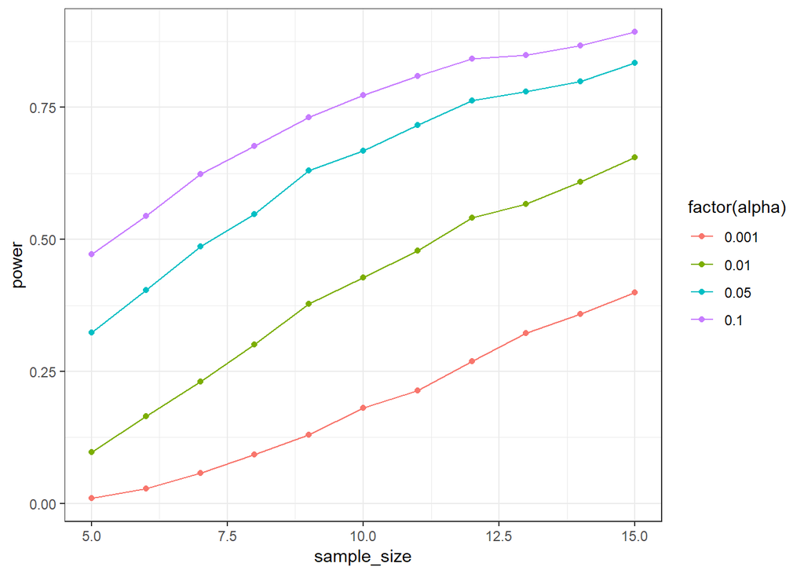

```r
  ##fit models##

 lim_fit <- function(sim_parameters){
  fit <- sim_parameters %>%
    group_by(sim, intercept, slope, residual_sd, sample_size) %>%
    nest() %>%
    mutate(mod = purrr:::map(data, ~lm(length.cm ~ age.days, data=.))) %>%
    mutate(coefs = purrr::map(mod, ~broom::tidy(.))) %>%
    unnest(coefs) %>%
    ungroup() %>%
    filter(term == "age.days")
  }
sim_fit <- lim_fit(sim_parameters= sim_parameters)

#power for intercept change
 pow_intercept <- sim_fit %>%
   crossing(alpha= c(0.001, 0.01, 0.05, 0.1))%>%
   group_by(intercept, alpha)%>%
   mutate(power=1-sum(p.value>alpha)/n()) %>%
   ungroup()

###Rinse and repeat for residual sd, and sample size
pow_resid <- sim_fit %>%
  crossing(alpha=c(0.001, 0.01, 0.05, 0.1)) %>%
  group_by(residual_sd, alpha) %>%
  mutate(power= 1- sum(p.value>alpha)/n()) %>%
  ungroup()

pow_samp_siz <- sim_fit %>%
  crossing(alpha= c(0.001, 0.01, 0.05, 0.1))%>%
  group_by(sample_size, alpha) %>%
  mutate(power=  1- sum(p.value>alpha)/n()) %>%
  ungroup()

#plot
inter_plot <- ggplot(data = pow_intercept,
       mapping = aes(x = intercept, y = power, color = factor(alpha))) +
  geom_point() +
  geom_line() +
  theme_bw()
resid_plot<- ggplot(data = pow_resid,
       mapping = aes(x = residual_sd, y = power, color = factor(alpha))) +
  geom_point() +
  geom_line() +
  theme_bw()
samp_siz_plot <- ggplot(data = pow_samp_siz,
       mapping = aes(x = sample_size, y = power, color = factor(alpha))) +
  geom_point() +
  geom_line() +
  theme_bw()

#visualize#
samp_siz_plot
```

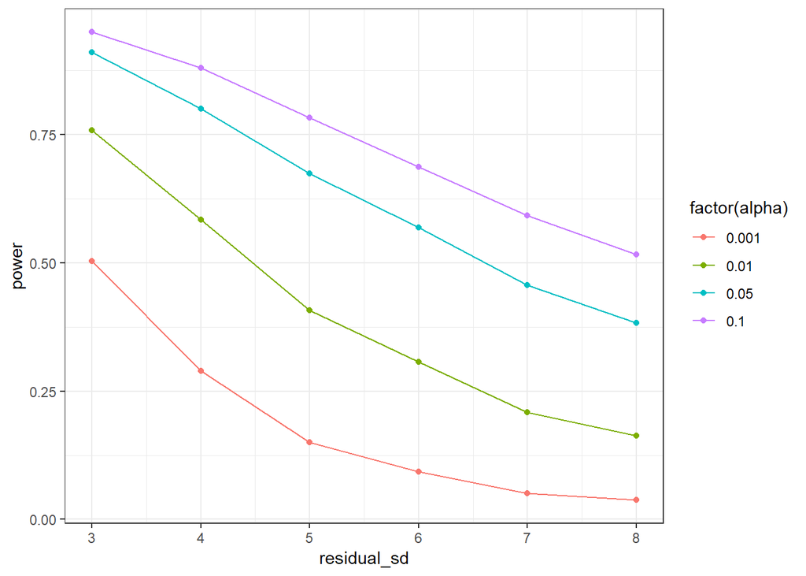

```r
resid_plot
```

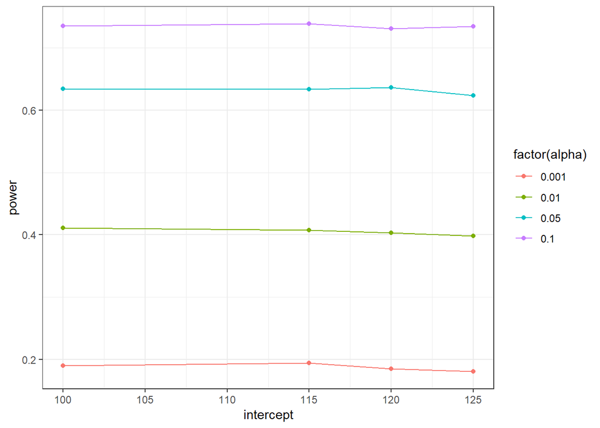

```r
inter_plot
```

Change in intercept did not have a significant effect on power, increasing residual variance had a negative effect on power and larger sample sizes increased power.

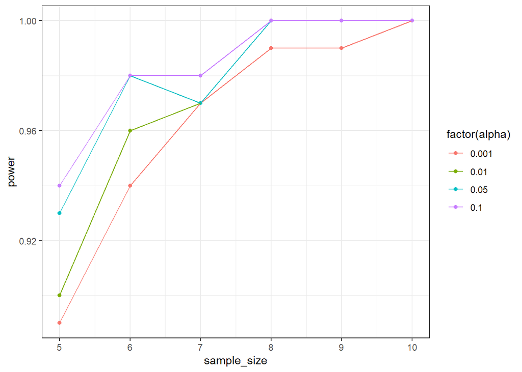

```r
#EC: Extra credit 1 - test whether the distribution of ages alters power: 3 points

sim_log<- data.frame(intercept = 115.767,
                      slope= 0.00237, residual_sd = 5.6805) %>%
 crossing(sample_size = 5:10) %>%
group_by(intercept, slope, residual_sd, sample_size) %>%
    expand(reps= 1:sample_size) %>%
    ungroup() %>%
    #replicate for simulations
    crossing(sim= 1:100) %>%
    mutate(age.days= rlnorm(n(), log(3730.246), log(1293.485))) %>%
    mutate(length.cm = rnorm(n(), intercept + slope* age.days,
                             residual_sd)) %>%
    ungroup()

#fit
log_fit <- sim_log %>%
    group_by(sim, sample_size) %>%
    nest() %>%
    mutate(mod = purrr:::map(data, ~lm(length.cm ~ age.days, data=.))) %>%
    mutate(coefs = purrr::map(mod, ~broom::tidy(.))) %>%
    unnest(coefs) %>%
    ungroup() %>%
    filter(term == "age.days")
#power
pow_age_distrib <- log_fit %>%
  crossing(alpha= c(0.001, 0.01, 0.05, 0.1))%>%
  group_by(sample_size, alpha) %>%
  mutate(power=  1- sum(p.value>alpha)/n()) %>%
  ungroup()
log_dis_plot <- ggplot(data = pow_age_distrib,
       mapping = aes(x = sample_size, y = power, color = factor(alpha))) +
  geom_point() +
  geom_line() +
  theme_bw()
log_dis_plot
```

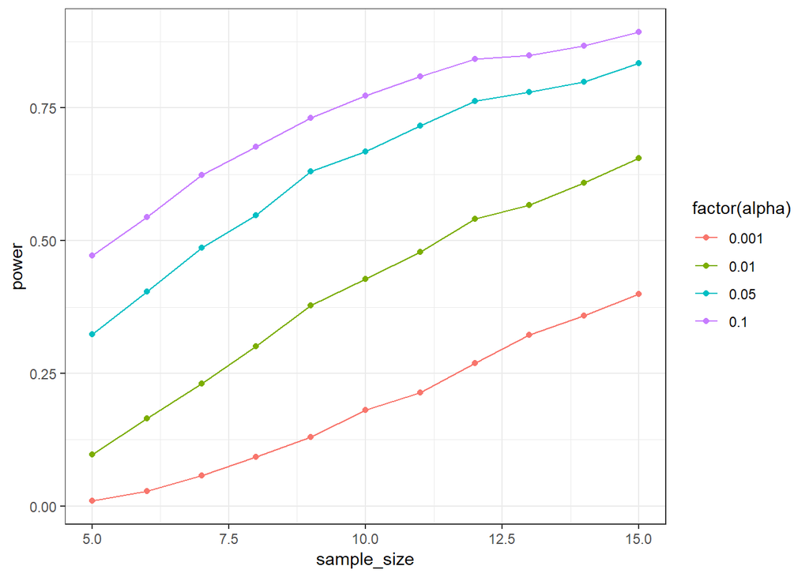

```r
samp_siz_plot
```

```r
P_E <- 0.0001
P_N <- 1- P_E #probabilit it doesn't explode
P_Y_E <- 35/36    #prob it says the sun explodes given that it did explode
P_Y_NE <- 1/36  #prob it says yes given the sun doesn explode (ie the prob of it lying)

#Prob of explostion give true= P(Y|E)* (P(E))/ P(Y)
#Prob of it being true P(Y)= P(Y|E) P(E) + P(Y|N) * P(N)


#our equation
#P(Exp |Yes) <- P(yes|explodes)*p(Explodes)/Prob(Yes)
#Prob(Y)= P(Says Ex | explodes)*P(E) + P(Says ex|doesnt)* P(N)

P_Y <- P_Y_E*P_E + P_Y_NE*P_N

P_exp_given_data <- (P_Y_E* P_E)/P_Y
P_exp_given_data
```

```
## [1] 0.00348814
```

We want to know the probability of the sun exploding given the machine says yes P(E| Y) The probability the sun explodes given the data is 0.0035.

## 5 Quailing at the Prospect of Linear Models

I’d like us to walk through the three different ‘engines’ that we have learned about to fit linear models. To motivate this, we’ll look at Burness et al.’s 2012 study “Post-hatch heat warms adult beaks: irreversible physiological plasticity in Japanese quail

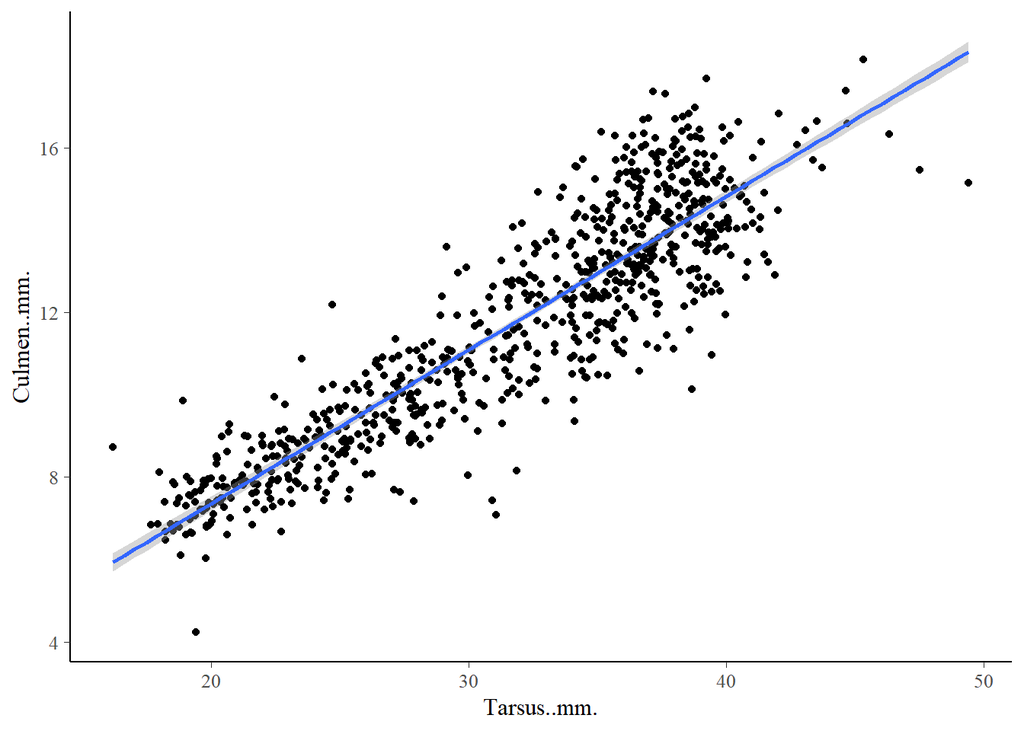

```r
library(readr)
library(profileModel)
morph <- read.csv("./Data/Morphology data.csv")
morph <- morph %>% na.omit()    #getting rid of NAs
#visualize data
ggplot(data= morph, aes(x=Tarsus..mm., y=Culmen..mm.))+ geom_point()+
  stat_smooth(method= "lm")
```

### 5.1 Three fits (10 points)

To begin with, I’d like you to fit the relationship that describes how Tarsus (leg) length predicts upper beak (Culmen) length. Fit this relationship using least squares, likelihood, and Bayesian techniques. For each fit, demonstrate that the necessary assumptions have been met. Note, functions used to fit with likelihood and Bayes may or may not behave well when fed NAs. So look out for those errors.

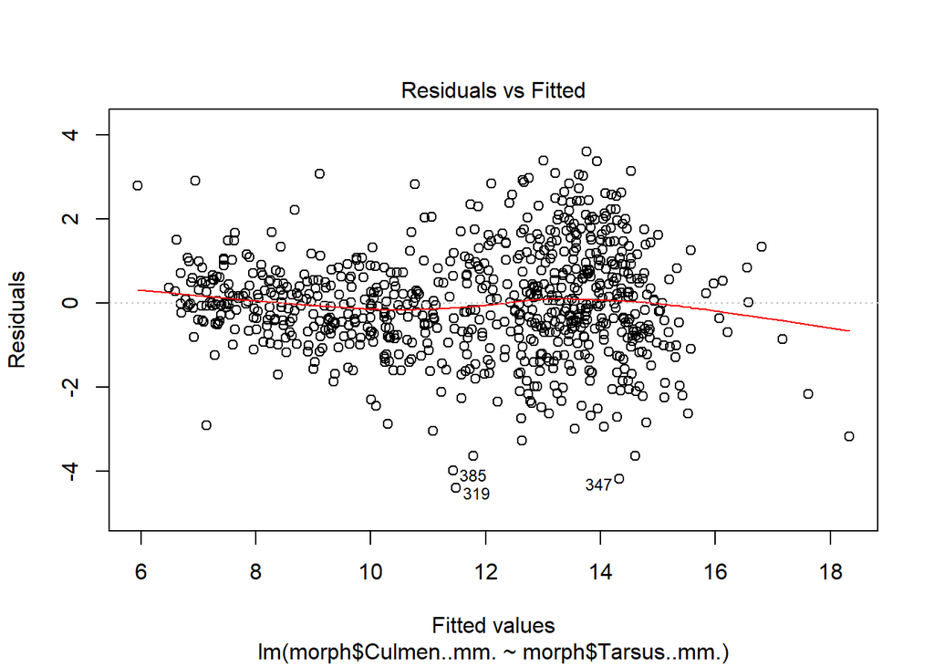

```r
#fit with least squares
morph_mod <- lm(morph$Culmen..mm.~ morph$Tarsus..mm.)
#check assumptions
plot(morph_mod, which=1)
```

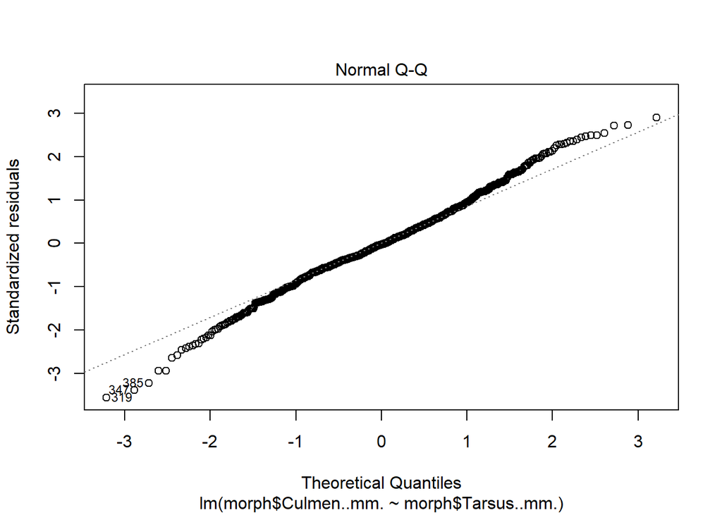

```r
plot(morph_mod, which=2) #qq-plot looks a little weird on ends
```

```r
#tests
anova(morph_mod) #t-test
```

```
## Analysis of Variance Table
##
## Response: morph$Culmen..mm.
##                    Df Sum Sq Mean Sq F value    Pr(>F)
## morph$Tarsus..mm.   1 4829.3  4829.3    3149 < 2.2e-16 ***
## Residuals         764 1171.7     1.5
## ---
## Signif. codes:  0 '***' 0.001 '**' 0.01 '*' 0.05 '.' 0.1 ' ' 1
```

```r
summary(morph_mod) #High F value, looks good
```

```
##
## Call:
## lm(formula = morph$Culmen..mm. ~ morph$Tarsus..mm.)
##
## Residuals:
##     Min      1Q  Median      3Q     Max
## -4.4081 -0.7029 -0.0328  0.7263  3.5970
##
## Coefficients:
##                    Estimate Std. Error t value Pr(>|t|)
## (Intercept)       -0.098707   0.215450  -0.458    0.647
## morph$Tarsus..mm.  0.372927   0.006646  56.116   <2e-16 ***
## ---
## Signif. codes:  0 '***' 0.001 '**' 0.01 '*' 0.05 '.' 0.1 ' ' 1
##
## Residual standard error: 1.238 on 764 degrees of freedom
## Multiple R-squared:  0.8048, Adjusted R-squared:  0.8045
## F-statistic:  3149 on 1 and 764 DF,  p-value: < 2.2e-16
```

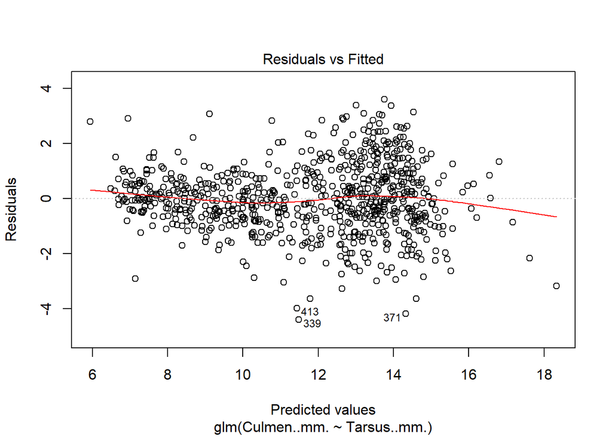

```r
#fit with likelihood
morph_glm <- glm(Culmen..mm.~Tarsus..mm.,
                 data=morph,
                 family= gaussian(link="identity"))
#check assumptions
#assumptions
m_fit <- predict(morph_glm)
m_res <- residuals(morph_glm)

plot(morph_glm, which=1)
```